# Reproducible Research - Week2, Course Project 1

Kerstin Funke

8/8/2021

## Loading and preprocessing the data

First, we will load the data, format the Date variable and build a new data frame which aggregates the number of steps per day.

```r
library(dplyr)
```

```r
activity <- read.csv("activity.csv",
                     header = TRUE,
                     sep = ",",
                     na.strings = "NA")

activity$date <- as.Date(activity$date, "%Y-%m-%d")

activityDay <- aggregate(activity$steps,
                         by = list(date=activity$date),
                         FUN=sum)
activityDay<- rename(activityDay, steps = x)
```

## Mean total number of steps taken per day

Here you can see a histogram of steps taken per day.

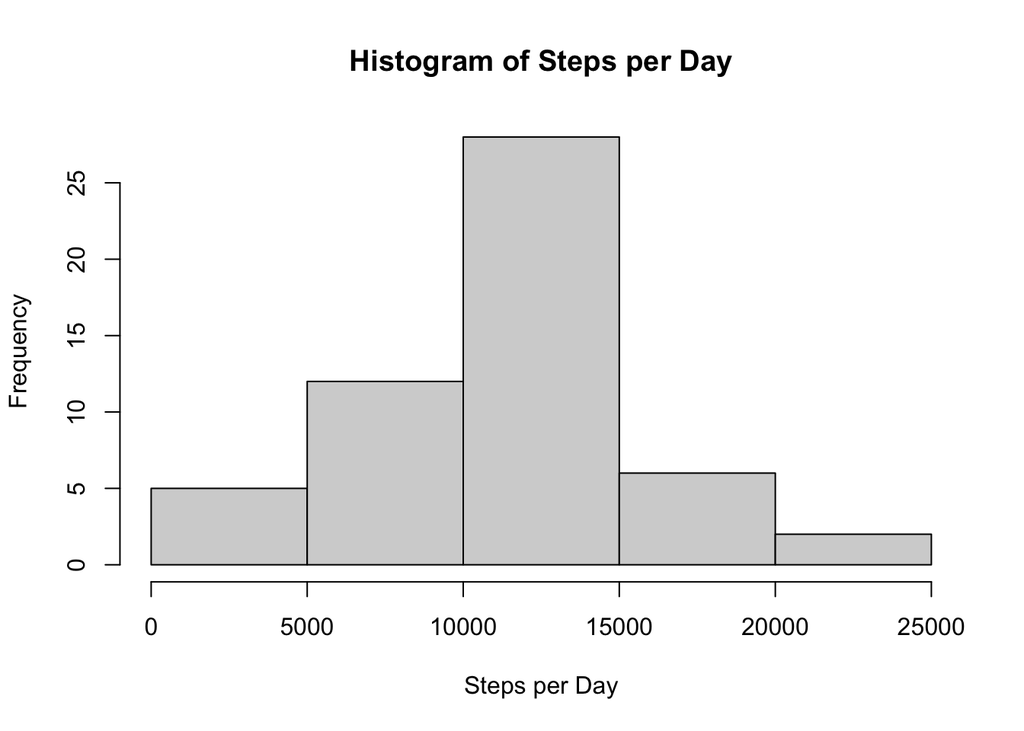

```r
hist(activityDay$steps,
     xlab="Steps per Day",
     main="Histogram of Steps per Day")
```

Here are the mean and the median of steps taken per day.

```r
mean(activityDay$steps,na.rm = TRUE)
```

```
## [1] 10766.19
```

```r
median(activityDay$steps,na.rm = TRUE)
```

```
## [1] 10765
```

So the mean of the total number of steps taken per day is 10766.19 and the median is 10765.

## Average daily activity pattern

First, we build a new data frame which shows the average number of steps per interval across all days.

```r
activityInterval <- aggregate(activity$steps,
                              by = list(interval=activity$interval),
                              FUN=mean, na.rm = TRUE)
activityInterval<- rename(activityInterval, steps = x)
```

Then, we build a time series plot of the 5-minute interval (x-axis) and the average number of steps taken, averaged across all days (y-axis)

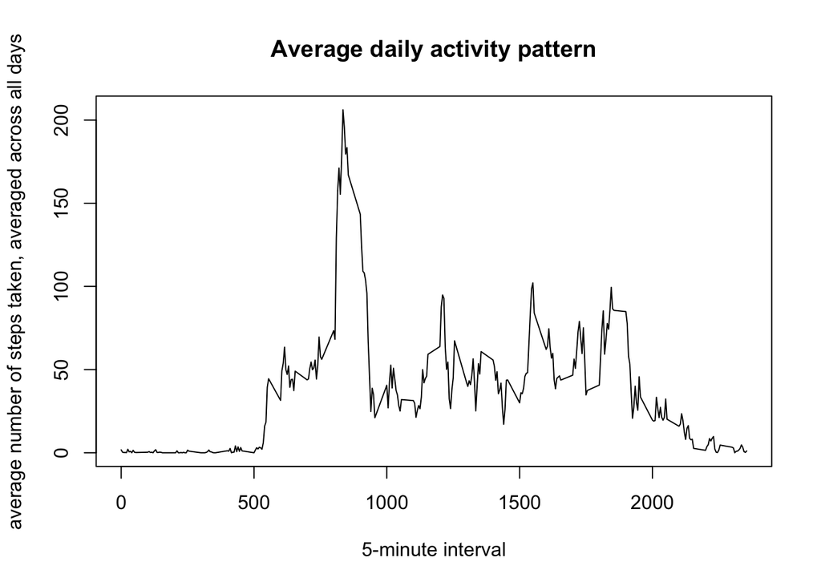

```r
plot(activityInterval$interval, activityInterval$steps,
     type="l",
     xlab="5-minute interval",
     ylab="average number of steps taken, averaged across all days",
     main="Average daily activity pattern")
```

We then identify which 5-minute interval, on average across all the days in the dataset, contains the maximum number of steps.

```r
activityInterval$interval [which.max(activityInterval$steps)]
```

```
## [1] 835
```

This shows that on average across all the days in the dataset the 5-minute interval at 8:35am shows the highest number of steps.

## Imputing missing values

First we determine the number of missing values in the original data set

```r
sum(!complete.cases(activity$steps))
```

```
## [1] 2304
```

Overall there are 2304 missing values.

```r
activityMissing <- activity
activityMissing$steps[is.na(activityMissing$steps)] <- mean(activityMissing$steps, na.rm=TRUE)
```

As a next step we build a new data frame which aggregates the number of steps per day using the new data set

```r
activityDayMissing <- aggregate(activityMissing$steps,
                                by = list(date=activityMissing$date),
                                FUN=sum)
activityDayMissing<- rename(activityDayMissing, steps = x)
```

Then we make a histogram of the total number of steps taken each day using this new data frame.

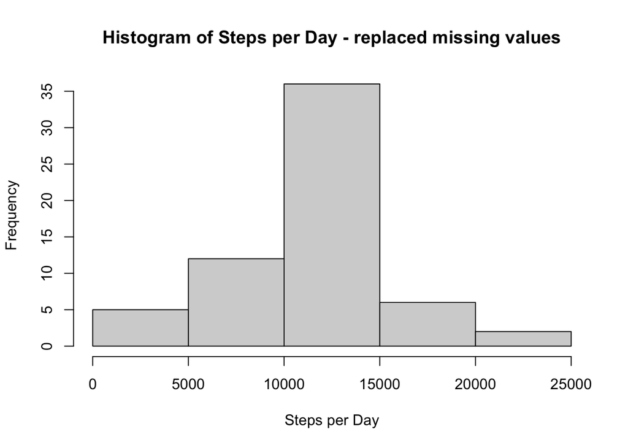

```r
hist(activityDayMissing$steps,
     xlab="Steps per Day",
     main="Histogram of Steps per Day - replaced missing values")
```

We then recalculate the mean and median

```r
mean(activityDayMissing$steps,na.rm = TRUE)
```

```
## [1] 10766.19
```

```r
median(activityDayMissing$steps,na.rm = TRUE)
```

```
## [1] 10766.19
```

The results show that the mean stayed the same and the median now equals the mean.

## Differences in activity patterns between weekdays and weekends

In order to identify potential differences in activity patterns between weekdays and weekends we set up new variables - first, a variable that identifies the different weekdays and then we recode those weekdays into a variable called ‘weekend’ that distinguishes between weekend and weekday.

```r
activityMissing$weekdays <- weekdays(activityMissing$date, abbreviate = FALSE)

activityMissing$weekend<-recode( activityMissing$weekdays,
                                 "Saturday" = "Weekend",
                                 "Sunday" = "Weekend",
                                 .default = "Weekday")
```

Now we build a data set that shows how many steps participants took on average per interval on weekdays vs. weekends.

```r
activityDayMissingInterval <- aggregate(activityMissing$steps,
                                       by = list(interval=activityMissing$interval, weekend=activityMissing$weekend),
                                       FUN=mean, na.rm = TRUE)
activityDayMissingInterval <- rename(activityDayMissingInterval , steps = x)
```

In a second step we then set up two time series plots looking at the development throughout the day (using 5-minute intervals) on weekends (plot 1) and weekdays (plot 2)

```r
library(lattice)
```

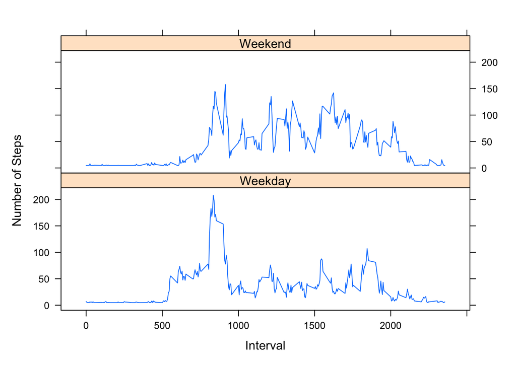

```r
xyplot( steps ~ interval| weekend,
        data =  activityDayMissingInterval,
        type = "l",
        layout=c(1,2),
        ylab="Number of Steps",
        xlab="Interval")
```